# STATS 205 Homework 6

Julie Zhu

May 26, 2016

We will first load in the libraries for this homework assignment. There are quite a few packages I used for small conversions this week.

```r
# Libraries
library(datasets)
library(dplyr)
library(tidyr)
library(ggplot2)
library(readr)
library(purrr)
library(waveslim)
library(reshape2)
```

## Exercise 1

In this problem, we want to understand wavelets and function estimation using the sunspots data. The sunspots data stores monthly mean relative sunspot numbers from 1749 to 1983. The data were collected in Zurich, Switzerland until 1960 and then in Tokyo, Japan from then onward.

For some data background, sunspots are temporary phenomena on the photosphere of the sun that appear visibly as dark spots compared to surrounding regions. The measurements in the data correspond to concentrations of magnetic field flux that inhibit convection and result in reduced surface temperature compared to the surrounding regions.

We first use the `dwt` command to obtain the wavelet coefficients of the first 512 components of the sunspots data. We will use $n.levels = 9$. The `dwt` command determines the wavelet coefficients at each resolution level (in this case, we have 9 resolution levels).

```r
sun_comps <- sunspots[1:512]
# Wavelet Decomposition
sun_dwt <- dwt(sun_comps, n.levels = 9)
```

### Part A

In this part of the problem, we explore the sparsity of the data representation. We use the `unlist` command on the output of the `dwt` command to create a single vector of coefficients from all resolution levels (from the highest to the lowest).

```r
sun_coefs <- sun_dwt %>% unlist()
```

Next, we make two histograms: one of the coefficient vector from the `unlist` function and one of the untransformed sunspots data (first 512 components).

How do these histogram shapes illustrate the sparsity of the wavelet representation of the data?

We first create a data frame that binds the two sets of values that we want and create the two histograms. We see that the left panel is a histogram of the coefficients obtained from `dwt` and the right panel is a histogram of the original sunspots data.

We limited the values to see the distribution a little more clearly and for easier comparison between the two distributions. At a first glance, we see that the untransformed sunspots data is right-skewed and all positive whereas the distribution of the coefficients seem to be concentrated around 0.

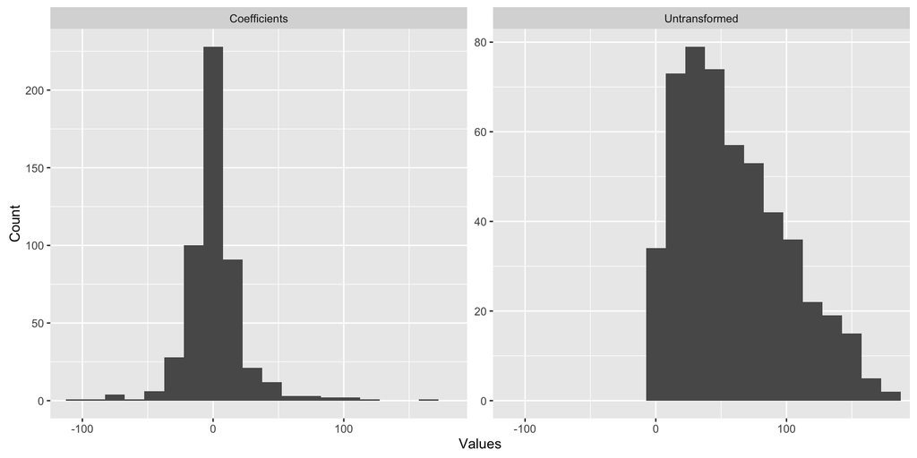

```r
sun_hist <- data_frame(Untransformed = sun_comps, Coefficients = sun_coefs)

# Plot histograms side-by-side
sun_hist %>%
  gather(set, value, Untransformed:Coefficients) %>%
  ggplot() +
  geom_histogram(mapping = aes(x = value), binwidth = 15) +
  facet_wrap( ~ set, scales = "free_y") +
  coord_cartesian(x = c(-110, 180)) +
  labs(x = "Values", y = "Count")
```

Taking a closer look at the coefficient histogram by itself without limiting the axes, we see that there are a lot of coefficients centered on or around 0. There are a few select coefficients that are significantly negative and a few coefficients that are overwhelmingly positive.

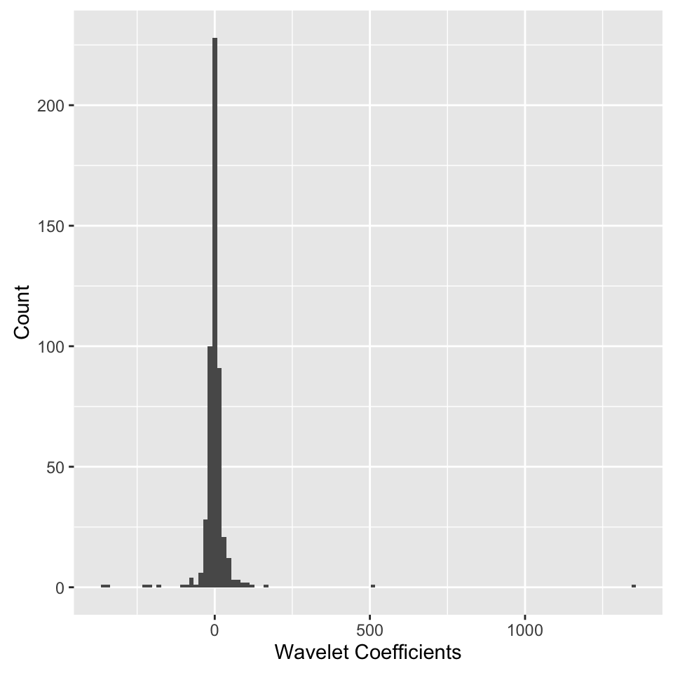

```r
data_frame(sun_coefs = sun_coefs) %>%
  ggplot() +
  geom_histogram(mapping = aes(x = sun_coefs), binwidth = 15) +
  labs(x = "Wavelet Coefficients", y = "Count")
```

Looking at the untransformed sunspots data, we see that the data is heavily right-skewed (as shown before). There are few “extreme” values and a lot of the data seem to be around the 0 to 100 range.

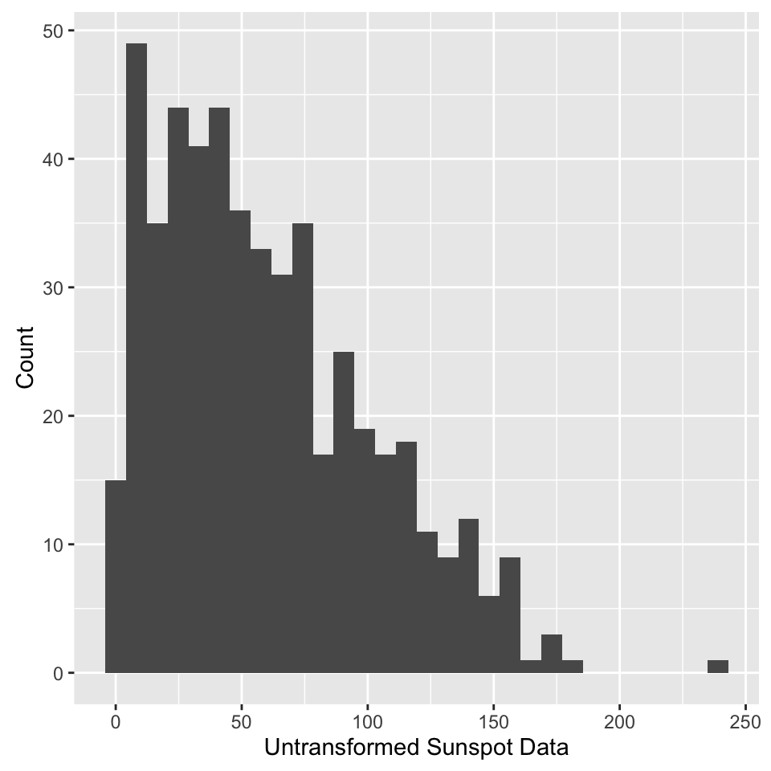

```r
data_frame(sun_comps = sun_comps) %>%
  ggplot() +
  geom_histogram(mapping = aes(x = sun_comps)) +
  labs(x = "Untransformed Sunspot Data", y = "Count")
```

Since most of our coefficients are near 0 or 0, we see that these coefficients weight our data such that a lot of them are regularized towards 0. This means that a lot of our data becomes small and trivial. Some of the data is more heavily weighted since we have a few really large coefficients.

### Part B

In this problem, we want to create a histogram using only the highest level of detail coefficients. Do these coefficients appear to be symmetric about 0? Normal?

We see that the highest level of detail coefficients are indeed centered around 0. However, we don’t see the distribution as being completely normal because there seems to be a slight skew to the right.

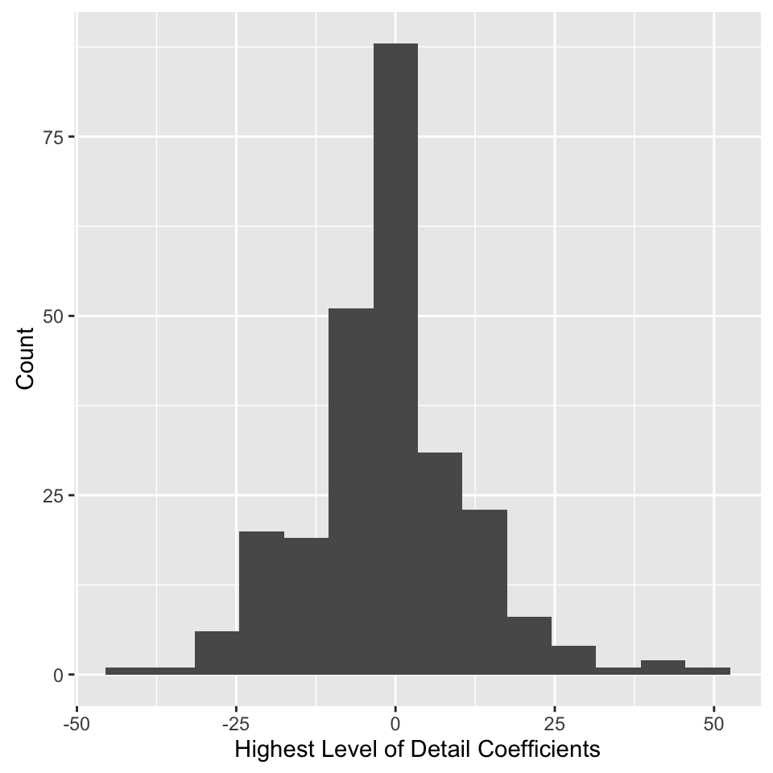

```r
data_frame(high_coef = sun_dwt$d1) %>%
  ggplot() +
  geom_histogram(mapping = aes(x = high_coef), binwidth = 7) +
  labs(x = "Highest Level of Detail Coefficients", y = "Count")
```

### Part C

In this part of the problem, we want to compare the two thresholding measures SureShrink and VisuShrink (hard and soft thresholds). We will use the package `waveslim` and then go through the differences in the reconstructions.

$\textbf{SureShrink}$

From the referenced book, we will use the `hybrid.thresh` function with the default settings of `max.level = 4`. This thresholds the wavelet coefficients in the four detail resolution levels. We then use the inverse function to obtain the original points for the function estimation.

```r
sure_thresh <- hybrid.thresh(sun_dwt)
sure_idwt <- idwt(sure_thresh)
```

We overlay the SureShrink fit onto the original data. The original data is the black line while the SureShrink fit is noted in red. The SureShrink fit gives a pretty smooth fit of the original data. Note that SureShrink only uses soft thresholding.

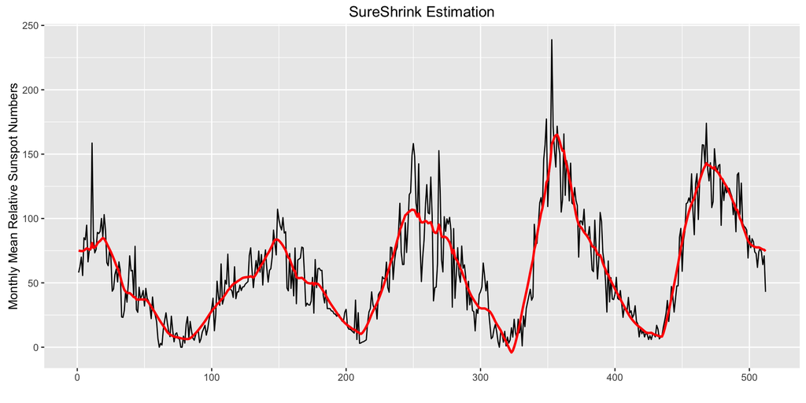

```r
ggplot() +
  geom_line(mapping = aes(x = 1:length(sun_comps), y = sun_comps)) +
  geom_line(mapping = aes(x = 1:length(sun_comps), y = sure_idwt),
            color = "red",
            size = 1) +
  labs(x = "", y = "Monthly Mean Relative Sunspot Numbers",
       title = "SureShrink Estimation")
```

$\textbf{VisuShrink}$

Then, we use `universal.thresh` to perform VisuShrink with the default settings of `max.level = 4`. We then use the inverse function to obtain the original points for the function estimation.

We will first go through the $\textbf{hard threshold}$ for VisuShrink.

```r
visu_thresh <- universal.thresh(sun_dwt, hard = TRUE)
visu_idwt <- idwt(visu_thresh)
```

We overlay the hard VisuShrink fit onto the original data. The original data is the black line while the hard VisuShrink fit is noted in red. The VisuShrink fit gives a pretty good fit of the original data, but is more variable than the SureShrink fit.

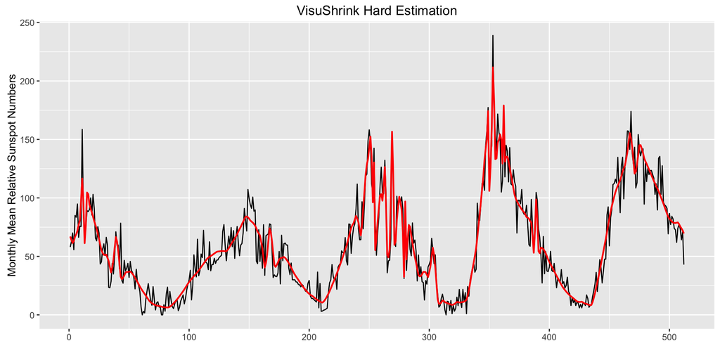

```r
ggplot() +
  geom_line(mapping = aes(x = 1:length(sun_comps), y = sun_comps)) +
  geom_line(mapping = aes(x = 1:length(sun_comps), y = visu_idwt),
            size = 0.8,
            color = "red") +
  labs(x = "", y = "Monthly Mean Relative Sunspot Numbers",
       title = "VisuShrink Hard Estimation")
```

We also do the $\textbf{soft thresholding}$ method for VisuShrink.

```r
visu_thresh_soft <- universal.thresh(sun_dwt, hard = FALSE)
visu_idwt_soft <- idwt(visu_thresh_soft)
```

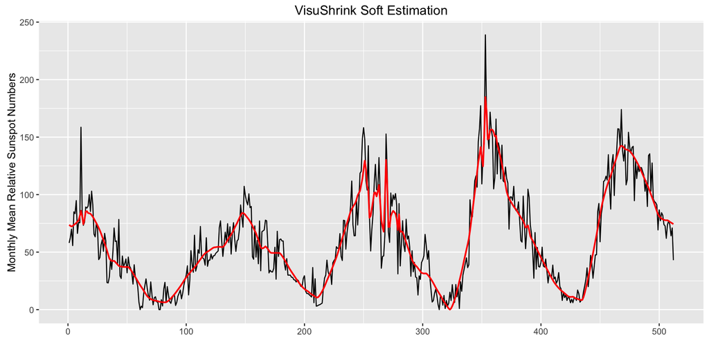

```r
ggplot() +
  geom_line(mapping = aes(x = 1:length(sun_comps), y = sun_comps)) +
  geom_line(mapping = aes(x = 1:length(sun_comps), y = visu_idwt_soft),
            color = "red",
            size = 0.8) +
  labs(x = "", y = "Monthly Mean Relative Sunspot Numbers",
       title = "VisuShrink Soft Estimation")
```

Looking at the two reconstructions, we see that the SureShrink estimation is smoother and has less jumps in its plot. This shows that since SureShrink reduces the non-zero coefficients to zero, it’ll have a smoother and less jumpy estimated wavelet. The smoothness of the SureShrink estimation makes the fit more robust against noisy data as it doesn’t fit to the data as much as VisuShrink, in this case.

$\textbf{Differences in Reconstruction}$

The VisuShrink method gives a universal threshold on the wavelet coefficients for each level of resolution when we are estimating the function.  
Note that the VisuShrink method provides an optimal reconstruction of the matrix only in the case of normally distributed errors.

The SureShrink method has different thresholds for each level of resolution where the VisuShrink has only one threshold for all the levels. When implementing SureShrink, we might notice that some wavelet coefficients might be too sparse at certain resolution levels (perhaps due to lack of information), thus we can’t determine a threshold level. In this case, the SureShrink method will use VisuShrink (hence the hybrid method of SureShrink).

## Exercise 2

We will analyze the a network from SNAP using Universal Singular Value Thresholding (USVT). The network we obtained from the SNAP website is the Arxiv GR-QC (General Relativity and Quantum Cosmology) collaboration network. It covers scientific collaborations between authors papers submitted to the General Relativity category.

The SNAP website gives the following description of the edge list.

“If an author i co-authored a paper with author j, the graph contains a undirected edge from i to j. If the paper is co-authored by k authors this generates a completely connected graph on k nodes.”

```r
relativity <- read_delim(file = "general_relativity.txt",
                         col_names = TRUE, skip = 3, delim = "\t") %>%
  rename(from_node = `# FromNodeId`, to_node = ToNodeId)
```

We have a total of 5242 unique nodes and 14,496 edges total after reading in the data.

### Part A

We will implement the USVT algorithm using $\eta = 0.01$. We will follow the algorithm in the slides from the lecture `Graph Limits or Graphons`.

We will assume that all of our entries in our adjacency matrix is observed and we do not know what is not observed. Thus, we will have no 0 values in our Y matrix and our p_hat value will be set to a default of 0.25 (as assumed in the MATLAB code and suggested by the TAs).

```r
usvt_implement <- function(X, eta = 0.01) {
  # Define the maximum and minimum of the adjacency graph
  max_X <- max(X)
  min_X <- min(X)
  # Obtain the number of nodes and the proportion of observed
  n <- nrow(X)
  # According to the TA, we should assuming that all of our graph is observed
  # Use a fixed p_hat value
  p_hat <- 0.25
  # Normalize the values of our adjacency matrix to the range [-1, 1]
  norm_X <- (X - (max_X + min_X)/2)/((max_X - min(X))/2)
  Y <- norm_X
  #Y[X == 0] <- 0
  # Perform SVD
  singular_decomp <- svd(Y)
  U <- singular_decomp$u
  V <- singular_decomp$v
  S <- singular_decomp$d
  # Use the Singular Value Threshold
  singular_index <- (S < (2 + eta)*sqrt(n*p_hat))
  S1 <- S;
  S1[singular_index] <- 0;
  # Perform SVD with only the singular values
  W <- U %*% diag(S1) %*% t(V)
  W <- W/p_hat
  # Construct estimation matrix
  M <- W
  M[W > 1] <- 1
  M[W < -1] <- -1
  # Re-map the estimations to the original range [0, 1]
  M <- (M*((max_X - min(X))/2)) + ((max_X + min_X)/2)
  return (M)
}
```

### Part B

We now rearrange the nodes according to the empirical degree. Then, we plot the reconstructed matrix with the rearranged columns and rows and without the rearranged columns and rows. We obtain the reconstructed matrix using our USVT implementation above.

To avoid the graph from becoming too sparse, we will use the nodes with the highest empirical degrees (the nodes connected to the most number of other nodes). We see that otherwise we get more than the specified number because of overlapping degrees.

```r
val_num <- 200
```

We first pick out the top 200 node names that have the highest empirical degrees out of the entire data set. To run it on the full data set, just set `val_num` equal to the count of all the nodes.

```r
# Create a character vector containing every node name
deg_rank <- relativity %>%
  count(from_node) %>%
  top_n(val_num) %>%
  arrange(-n) %>%
  .$from_node %>%
  unique()
```

We then create the new edge list for filtering for nodes that appear in the set that we created earlier. We also order the nodes by their empirical degree. We reverse the empirical degree ordering for the from node so that the nodes with the highest empirical degrees are concentrated in the upper left corner.

```r
# Not all of the nodes in the ranking will be present in the new data set
sorted_relativity <- relativity %>%
  filter(from_node %in% deg_rank,
         to_node %in% deg_rank) %>%
  mutate(to_node = factor(to_node, levels = deg_rank),
        from_node = factor(from_node, levels = rev(deg_rank)))
```

Now we take all of the top nodes and make an adjacency matrix. Note that when we construct the adjacency matrix, we have the nodes with the highest empirical degree on the upper left hand corner. This is because when we are getting the indices for our adjacency matrix according to the ordering of the nodes.

```r
size <- unique(sorted_relativity$to_node) %>% length()
table_adj <- matrix(0, nrow = size, ncol = size)

# Get a new internal ranking of empirical degree since we are only including
# `from_node` and `to_node`s that are in the top 200
new_rank <- sorted_relativity %>%
  count(from_node) %>%
  arrange(-n) %>%
  .$from_node %>%
  unique()

# Create adjacency matrix with ordered rows and columns
for (i in seq_len(nrow(sorted_relativity))) {
  x <- as.factor(sorted_relativity[i, 1] %>% unlist())
  y <- as.factor(sorted_relativity[i, 2] %>% unlist())
  index_i <- which(new_rank == x)
  index_j <- which(new_rank == y)
  table_adj[index_i, index_j] <- 1
}
```

We see that there are a total of 6042 edges/connections in our vetted data.

```r
sum(table_adj)
```

```
## [1] 6042
```

Now, we use the USVT implementation from Part A to obtain our estimated matrix.

```r
results <- usvt_implement(table_adj)
```

We name the columns and rows so that we can plot them and understand which nodes we are looking at.

```r
colnames(results) <- new_rank
rownames(results) <- new_rank
```

We melt our data so that we can have an edge list to plot with. This is sorted, so our graph hopefully will have some definite shape.

```r
ordered <- results %>%
  melt() %>%
  as_data_frame() %>%
  tbl_df() %>%
  # We want to order the edges by their empirical degree now that we
  # have an edgelist, not a matrix
  mutate(to_node = factor(Var1, levels = new_rank),
        from_node = factor(Var2, levels = rev(new_rank))) %>%
  select(-Var1, -Var2)
```

Looking at the reconstructed plot, we see that most nodes are connected with itself. This makes sense as each researcher is its own coauthor, thus there will be a edge from each node to itself. However, we don’t see this being the case in our actual data.

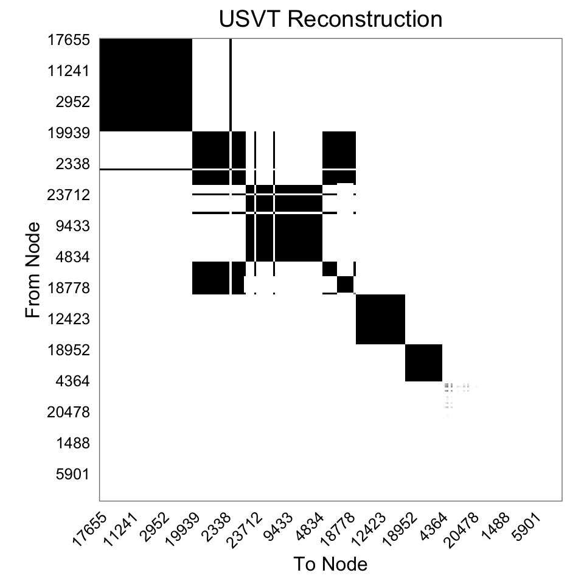

```r
# Plot Breaks
deg_breaks <- new_rank[seq(1, length(new_rank), by = 15)]

# Plot Reconstructed Matrix from USVT
ordered %>%
  ggplot() +
  geom_raster(mapping = aes(x = to_node, y = from_node, fill = value)) +
  theme_bw() +
  theme(aspect.ratio = 1,
        legend.position = "none",
        axis.ticks = element_blank()) +
  scale_y_discrete(breaks = deg_breaks) +
  scale_x_discrete(breaks = deg_breaks) +
  scale_fill_gradientn(colours = c("white", "grey50", "black")) +
  theme(axis.text.x = element_text(angle = 45, hjust = 1)) +
  labs(x = "To Node", y = "From Node", title = "USVT Reconstruction")
```

We now compare it to the original sorted adjacency matrix for our data. Note that along the diagonal, not a lot of authors have a link connected to himself or herself. It’s a lot less filled in than our reconstructed matrix, but the overall shape of the large square, medium square, and small square exist.

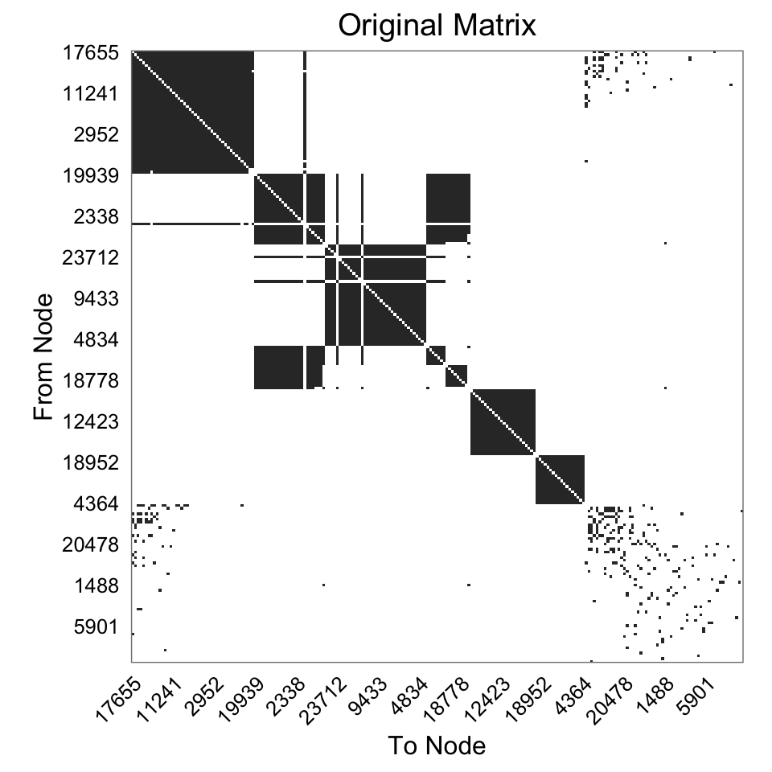

```r
#Plot Original Sorted Adjacency Matrix
sorted_relativity %>%
  filter(from_node %in% new_rank,
         to_node %in% new_rank) %>%
  mutate(to_node = factor(to_node, levels = new_rank),
        from_node = factor(from_node, levels = rev(new_rank))) %>%
  ggplot() +
  geom_raster(mapping = aes(x = to_node, y = from_node)) +
  theme_bw() +
  theme(aspect.ratio = 1,
        legend.position = "none",
        axis.ticks = element_blank()) +
  scale_y_discrete(breaks = deg_breaks) +
  scale_x_discrete(breaks = deg_breaks) +
  scale_fill_gradientn(colours = c("white", "black")) +
  theme(axis.text.x = element_text(angle = 45, hjust = 1),
        panel.grid.major = element_blank(),
        panel.grid.minor = element_blank()) +
  labs(x = "To Node", y = "From Node", title = "Original Matrix")
```

### Part C

In this section, we want to evaluate our results from the previous two steps. In our plotted matrices, we see that the reconstructed matrix actually captures the activity in the upper left-hand corner pretty well (even the black framing around node 2338). However, as we venture out to the lesser degree nodes, we see the matrix reconstruction makes some generalizations. We see a more scattered region of the original matrix plot in the bottom left and bottom right corners. However, the reconstructed plot makes the value of that area about the same and somewhat non-existent.

Something striking is that, as mentioned earlier, the diagonal is colored in for the reconstruction. This matrix says that authors who worked with many other prolific authors probably worked with themselves too.

We can probably interpret the middle few boxes as small clusters of authors who collaborate frequently with each other. They’re probably researchers in the same subfield of general relativity so their work is very similar.

But the authors with the highest empirical degree actually have a network outside of their immediate box (we see that they also have collaborated with the authors who have the smaller degree in the data set), but it since it is so sparse, our reconstruction did not pick it up.